# Analysis of RNA-seq data using Tophat and Cuffdiff

Gainova Kristina

19 12 2020

## Introduction

To capture the dynamic transcriptional response of Arabidopsis plants to HL stress, scientists performed a time course RNA sequencing (RNA-seq) study (doi:10.1016/j.celrep.2019.11.051). Arabidopsis seedlings were treated with high light (HL: 1,200 mmol m-2 s-1, leaf temperature: 22C) for 0.5, 6, 12, 24, 48, and 72 h with corresponding growth light (GL: 60 mmol m-2 s-1, leaf temperature: 22C) treatments as control. In this study samples treated with HL for 24 h with corresponding growth light (highlighted in yellow) were chosen for following analysis with Tophat and Cuffdiff.

## Goal and objectives

The goal of this study is analysis of RNA-seq data using Tophat and Cufflinks to identify the core HL-responsive genes

Objectives: 1. Quality control with FastQC 2. Splice-aware mapping RNA-seq reads to a reference genome using TopHat 3. Counting genes associated with genes and statistical analysis to identify DEGs using Cuffdiff 4. Data visualization with R

## Data

### RNA-seq reads

To find numbers of SRR samples visit this site https://trace.ncbi.nlm.nih.gov/Traces/study/ and enter SRP number. Raw RNA-Seq data from Arabidopsis GEO: GSE111062; SRP133385, Run: SRR6767639, SRR6767640 (GL, 24h) ; SRR6767652, SRR6767653 (HL, 24h). Library of single-end Illumina data, 51 bp: with 2 biological replicates for each sample.

| Run | Source_name | TREATMENT |
| --- | --- | --- |
| SRR6767639 | GL24h, | 7-day old whole seedlings Growth light (60 µmol.m-2.s-1, 22 oC) |
| SRR6767640 | GL24h, | 7-day old whole seedlings Growth light (60 µmol.m-2.s-1, 22 oC) |
| SRR6767652 | HL24h, | 7-day old whole seedlings High light (1200 µmol.m-2.s-1, leaf temperature: 22 |
| SRR6767653 | HL24h, | 7-day old whole seedlings High light (1200 µmol.m-2.s-1, leaf temperature: 22 |

I downloaded all SRR using command in command line

~$ prefetch SRR_number

All files restore into **path/ncbi/public/sra**. Sratoolkit is needed to convert SRR into fastq format, command

~$ fastq-dump SRR_number

File will be saved into **path/** as **SRR_number.fastq**

To view of SRR file content, type:

~$ less SRR6767639.fastq

Example of output:

@SRR6767639.4 4 length=51

NTCAGCTTATGGTACCTATACTCAATGAAGTGAGTGAAACACTGAAAGATA

+SRR6767639.4 4 length=51

#<<BBFFFFFFFFFFFFFFFFFFFFFFFFFFFFFFFFFFFFFFFFFFFFFF

### Genome and Annotation Data

The iGenome package for Arabidopsis (Ensembl, TAIR 10) downloaded, when unpacked, appears as Arabidopsis_thaliana

**~$ wget http://igenomes.illumina.com.s3-website-us-east-1.amazonaws.com/Arabidopsis_thaliana/Ensembl/TAIR10/Arabidopsis_thaliana_Ensembl_TAIR10.tar.gz**

Within it, there is an Ensembl directory and then a TAIR10 directory. In the TAIR10 directory there are two directories: “Annotation” and “Sequence”. The necessary files are copied out into the working directory:

~$ cp Annotation/Genes/genes.gtf working_directory

~$ cp Sequence/Bowtie2Index/genome.* working_directory

## Programs and R packages

- FastQC v0.11.5
- TopHat v2.1.1
- bowtie2 version 2.3.4.1
- Cuffdiff v2.2.1
- Bioconductor (v 3.12.0, R version 4.0.3)
- package org.At.tair.db 3.12.0
- package clusterProfiler 3.18.0
- package enrichplot 1.10.1
- package DOSE 3.16.0
- package ggplot2 3.3.2
- package ggnewscale 0.4.4
- package ggridges 0.5.2
- package topGO 2.42.0

## Quality control

At the first, It was checked quality of raw reads using FastQC program (v0.11.5). The diagrams below demonstrate high quality of data. Thus read trimming is not required for mapping and quantification of RNA-seq reads.

To assess data quality type:

**~$ fastqc SRR_number.fastq

Result will be saved as html file. To view FastQC report use command:

~$ firefox SRR_number.html

**Adapter content**

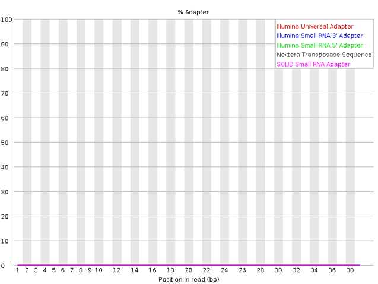

**Per base sequence quality**

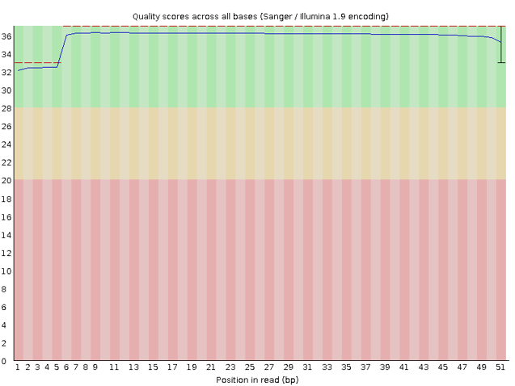

## Create bowtie2 index

If you want to create genome index own, you can use this command:

~$ bowtie2-build genome.fa genome

This program creates 6 files:

genome.1.bt2 genome.2.bt2 genome.3.bt2 genome.4.bt2 genome.rev.1.bt2 genome.rev.2.bt2

## TopHat2

Usage: **tophat [options]* <reads1_1[,…,readsN_1]> [reads1_2,…readsN_2]**

Starting with version 2.0.10 TopHat accepts mixed input file formats (FASTA/FASTQ).

Arguments:

**genome_index_base** The basename of the genome index to be searched. The basename is the name of any of the index files up to but not including the first period. Bowtie first looks in the current directory for the index files, then looks in the indexes subdirectory under the directory where the currently-running bowtie executable is located, then looks in the directory specified in the BOWTIE_INDEXES (or BOWTIE2_INDEXES) environment variable. **Please note that it is highly recommended that a FASTA file with the sequence(s) the genome being indexed be present in the same directory with the Bowtie index files** and having the name .fa. If not present, TopHat will automatically rebuild this FASTA file from the Bowtie index files.

**reads1_1[,…,readsN_1]** A comma-separated list of files containing reads in FASTQ or FASTA format. When running TopHat with paired-end reads, this should be the *_1 (“left”) set of files.

**[reads1_2,…readsN_2]** A comma-separated list of files containing reads in FASTQ or FASTA format. Only used when running TopHat with paired end reads, and contains the *_2 (“right”) set of files. The *_2 files MUST appear in the same order as the *_1 files.

Options:

**-i/–min-intron-length** The minimum intron length. TopHat will ignore donor/acceptor pairs closer than this many bases apart. The default is 70. **-I/–max-intron-length** The maximum intron length. When searching for junctions ab initio, TopHat will ignore donor/acceptor pairs farther than this many bases apart, except when such a pair is supported by a split segment alignment of a long read. The default is 500000.

### Running TopHat

Working directory must contains: reference genome and bowtie index files, annotation (GTF) and reads in format fastq

I used the following commands to map the RNA-seq reads to the genome:

~$ tophat -p 2 -i 20 -I 5000 -G genes.gtf -o SRR6767639_tophat genome SRR6767639.fastq

~$ tophat -p 2 -i 20 -I 5000 -G genes.gtf -o SRR6767640_tophat genome SRR6767640.fastq

~$ tophat -p 2 -i 20 -I 5000 -G genes.gtf -o SRR6767652_tophat genome SRR6767652.fastq

~$ tophat -p 2 -i 20 -I 5000 -G genes.gtf -o SRR6767653_tophat genome SRR6767653.fastq

Here, ‘SRR*******_tophat’ represents the output directory for each run. If no output directory is specified by the –o option, TopHat automatically creates a directory called tophat_out in the working director, and stores the output files in it. The values of the intron lengths are adjusted as 20bp and 5000 bp respectively for Arabidopsis thaliana instead of the default values which are for mammals.

See *Note 1* to read console messages.

**Error occurs during the execution of the program** samtools view: samtools view: writing to standard output failedwriting to standard output failed: Broken pipe : Broken pipe samtools view: error closing standard output: -1

The successful run creates a directory with the name specified by the user, containing the following files: **accepted_hits.bam**, **align_summary.txt**, **deletions.bed**, **insertions.bed**, **junctions.bed**, **prep_reads.info**, **unmapped.bam** and a directory with the name **logs**.

## Cuffdiff

Since it exists reference genome and annotation for Arabidopsis thaliana I skipped steps with Cufflinks and Cuffmerge (*de novo assembling* step) and used Cuffdiff program.

Cuffdiff program is used to find significant changes in transcript expression, splicing, and promoter use. Manual for Cuffdiff you can find here http://cole-trapnell-lab.github.io/cufflinks/cuffdiff/.

Cuffdiff options:

**-o/–output-dir * Sets the name of the directory in which Cuffdiff will write all of its output. The default is “./”. From the command line, run cuffdiff as follows:

**-L/–labels <label1,label2,…,labelN>** Specify a label for each sample, which will be included in various output files produced by Cuffdiff.

**-p/–num-threads** Use this many threads to align reads. The default is 1.

~$ cuffdiff –geometric-norm -p 16 -o cuffdiff_result_only genes.gtf -L GL_12h_control,HL_12h_treatment ./SRR6767639_tophat/accepted_hits.bam,./SRR6767640_tophat/accepted_hits.bam ./SRR6767652_tophat/accepted_hits.bam,./SRR6767653_tophat/accepted_hits.bam

Here parameter **–geometric-norm** was used for data normalization.

The successful run creates a directory with the name specified by the user, containing the following files: bias_params.info, gene_exp.diff, isoforms.fpkm_tracking, tss_group_exp.diff, cds.count_tracking, genes.count_tracking, isoforms.read_group_tracking, tss_groups.count_tracking, cds.diff, genes.fpkm_tracking, promoters.diff, tss_groups.fpkm_tracking, cds_exp.diff, genes.read_group_tracking, read_groups.info, tss_groups.read_group_tracking, cds.fpkm_tracking, isoform_exp.diff, run.info, var_model.info, cds.read_group_tracking, isoforms.count_tracking, splicing.diff

Needed file called gene_exp.diff. Initially I viewed content of the file and remove rows, where encountered value “inf” using command line:

~$ cat gene_exp.diff | grep -v “inf” > new_file.csv

## Data analysis in R

### Data preparation

Prepare dataframe with DEGs:

```
## 'data.frame':    31863 obs. of  13 variables:
##  $ gene_id          : chr  "AT1G01010" "AT1G01020" "AT1G01030" "AT1G01040" ...
##  $ gene             : chr  "NAC001" "ARV1" "NGA3" "DCL1" ...
##  $ locus            : chr  "1:3630-5899" "1:5927-8737" "1:11648-13714" "1:23145-33153" ...
##  $ sample_1         : chr  "GL_12h_control" "GL_12h_control" "GL_12h_control" "GL_12h_control" ...
##  $ sample_2         : chr  "HL_12h_treatment" "HL_12h_treatment" "HL_12h_treatment" "HL_12h_treatment" ...
##  $ status           : chr  "OK" "OK" "OK" "OK" ...
##  $ value_1          : num  7.35 8.47 2.73 8.61 18.08 ...
##  $ value_2          : num  13.77 9.36 2.37 8.01 9.84 ...
##  $ log2.fold_change.: num  0.906 0.143 -0.202 -0.105 -0.878 ...
##  $ test_stat        : num  3.639 0.52 -0.628 -0.28 -0.214 ...
##  $ p_value          : num  0.00005 0.46365 0.37365 0.692 0.72575 ...
##  $ q_value          : num  0.000355 0.655442 0.573339 0.829193 0.852027 ...
##  $ significant      : chr  "yes" "no" "no" "no" ...
```

```
##             gene_id    gene         locus       sample_1         sample_2
## AT1G01010 AT1G01010  NAC001   1:3630-5899 GL_12h_control HL_12h_treatment
## AT1G01020 AT1G01020    ARV1   1:5927-8737 GL_12h_control HL_12h_treatment
## AT1G01030 AT1G01030    NGA3 1:11648-13714 GL_12h_control HL_12h_treatment
## AT1G01040 AT1G01040    DCL1 1:23145-33153 GL_12h_control HL_12h_treatment
## AT1G01046 AT1G01046 MIR838A 1:23145-33153 GL_12h_control HL_12h_treatment
## AT1G01050 AT1G01050    PPA1 1:23145-33153 GL_12h_control HL_12h_treatment
##           status  value_1   value_2 log2.fold_change. test_stat p_value
## AT1G01010     OK  7.34869  13.76750          0.905703  3.638620 0.00005
## AT1G01020     OK  8.47499   9.36083          0.143425  0.520414 0.46365
## AT1G01030     OK  2.72991   2.37379         -0.201664 -0.628218 0.37365
## AT1G01040     OK  8.61131   8.00880         -0.104647 -0.279886 0.69200
## AT1G01046     OK 18.07570   9.83773         -0.877655 -0.214404 0.72575
## AT1G01050     OK 97.37570 111.31200          0.192971  0.669935 0.33245
##               q_value significant
## AT1G01010 0.000354903         yes
## AT1G01020 0.655442000          no
## AT1G01030 0.573339000          no
## AT1G01040 0.829193000          no
## AT1G01046 0.852027000          no
## AT1G01050 0.532547000          no
```

To do Gene Set Enrichment Analyssis with clusterProfilier package I need to transform gene_id (in my case it is TAIR id) to ETREZID.

### GSEA analysis

#### DotPlot

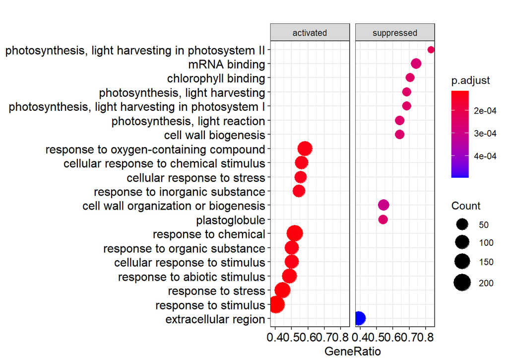

#### GseaPlot

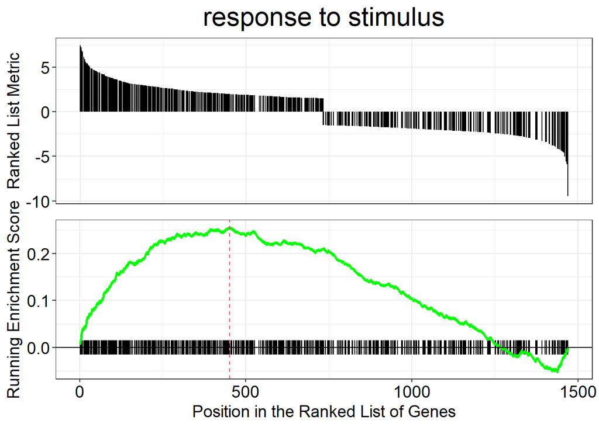

#### Encrichment Map

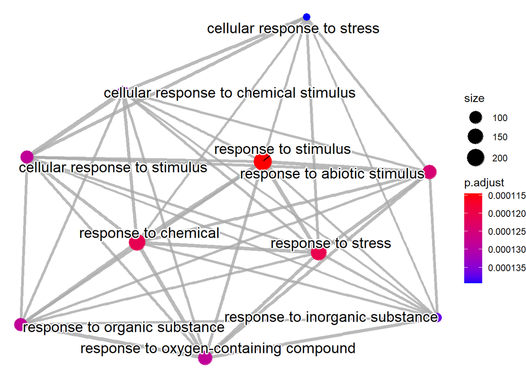

#### Volcano Plot

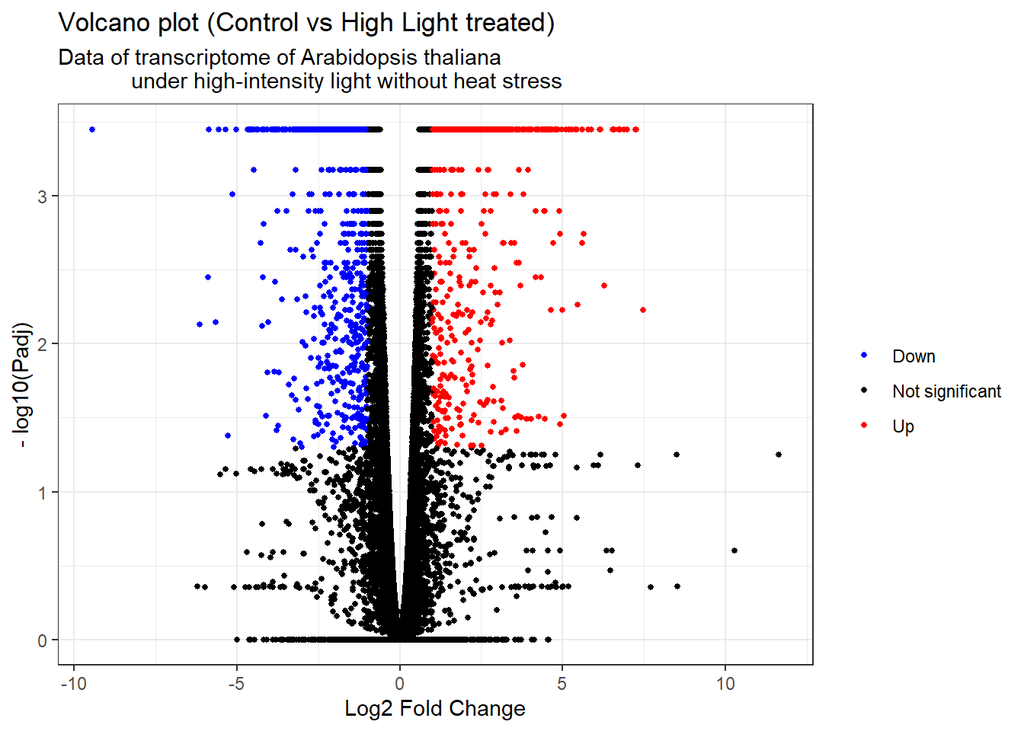

## Problems

Unfortunately normilization in cuffddif programs works awful! I find that for almost of genes q_value has same values. I decided to find amount of duplicated values in column “q_value” and it equals more 80 % of data!

Also using of pipeline cufflinks -> cuffmerge -> cuffdiff convert gene id to XLOC ** id. It makes difficult work with data.

Tophat2 v2.1.1 have some problems with error samtools view [samtools view: writing to standard output failedwriting to standard output failed: Broken pipe : Broken pipe samtools view: error closing standard output: -1] and unknown ways to solve this error.

## References

https://rstudio.com/wp-content/uploads/2015/03/rmarkdown-reference.pdf https://www.bioconductor.org/packages/release/data/annotation/manuals/org.At.tair.db/man/org.At.tair.db.pdf https://cran.r-project.org/web/packages/ggridges/vignettes/introduction.html https://learn.gencore.bio.nyu.edu/rna-seq-analysis/gene-set-enrichment-analysis/ https://rdrr.io/github/GuangchuangYu/enrichplot/man/pairwise_termsim.html Martin Morgan (2020). BiocVersion: Set the appropriate version of Bioconductor packages. R package version 3.12.0. Ghosh S, Chan CK. Analysis of RNA-Seq Data Using TopHat and Cufflinks. Methods Mol Biol. 2016;1374:339-61. doi: 10.1007/978-1-4939-3167-5_18. PMID: 26519415.